# Untitled

Chloe J McGovern

2025-04-17

# Goals

1. Load in phyloseq data with rooted tree & colors and functions.
2. Evaluate sequencing depth and remove samples, if needed.
3. Normalize the read counts between samples.
4. Calculate community **dis**similarities. Numbers between 0 and 1. If 0, completely similar versus if they are 1, then they’re completely dissimilar.
   1. **Sorensen**: Shared Species as a binary value: Abundance-unweighted
   2. **Bray-Curtis**: Shared Abundant species: Abundance-weighted
   3. **(Abundance-)Weighted UNIFRAC**: Consider Abundant Species and where they fall on the tree
5. Run statistics with functions from the vegan R package:
   1. PERMANOVA with `adonis2()`.
   2. betadispR with `betadisper()` and `permutest()`.
6. Visualize the community data with two unconstrained Ordinations:
   1. **PCoA**: Linear Method. Eigenvalue = how much variation is explained by each axis. Choose to view axis 1, 2, 3, etc. and plot them together.
   2. **NMDS**: Non-linear. Smush multiple Dimensions into 2 or 3 axes. Need to report Stress value (ideally <0.15).
1. We will need the `phytree_preprocessed_physeq.RData`, which includes a midpoint rooted tree that we created in `analysis/04B_Phylogenetic_Tree_Inspection.Rmd`.

NOTE: metadata may need to be hard coded in so I hope I don’t forget in the analysis when/if I get a error.

## Outputs

1. Calculated beta-diversity dissimilarity measures (*e.g.* Sorensen, Bray-Curtis, abundance-unweighted and -weighted UniFrac) across every sample.
2. Ordination figures (*i.e.,* PCoA/NMDS) to include in the scientific paper that visualize the data as it relates to the scientific question.
3. Statistical tests (*i.e.,* PERMANOVA & betadisper) conveying the measured and quantified changes and patterns in biodiversity.

# Scientific Question

## Question & Hypotheses

How is microbial biodiversity changed across different cheese types?

- *Null Hypothesis:* The microbial community does not change with cheese type.
- *Alternative Hypothesis:* Different cheese types have different microbial communities.

Interpretation 1: My hypothesis is that different cheese types WILL have different microbial communities. Or at least should…? Cheese is both delicious and complicated! There are varying moisture, textures, eyes/no eyes, tastes, rinds, no rinds…the list is extensive of the variation in cheese! I don’t know if the cheese types in this paper are distinct enough to detect the differences, but I think it is a valid hypothesis. One of the great things, is that supplemented with wet lab experiments, this paper could extend beyond the presence/absence and abundance it currently focuses on in terms of diversity. It could extend to phyogeny if additional characteristics were analyzed which could be kinda cool–the phylogeny of cheese bacteria!

# Set up

## Timing of this script

```r
# What time did we start running this script?
start_time <- Sys.time()
```

## Set the seed

```r
set.seed(238428)
```

## Load Packages, colors & functions

```r
pacman::p_load(tidyverse, devtools, phyloseq, patchwork, vegan,
               install = FALSE)

# Load Colors
source("code/colors.R")

cheese_colors <- c(
  "Colonial" = "lightpink1",
  "Feta-type" = "hotpink",
  "Fresh" = "deeppink3",
  "Pecorino-type" = "deeppink4")

# Load functions
source("code/functions.R")
```

# 1. Load in the data

```r
# load phyloseq object
load("data/04_PhylogeneticTree/phytree_preprocessed_physeqs.RData")
midpoint_rooted_physeq
```

```
## phyloseq-class experiment-level object
## otu_table()   OTU Table:         [ 93 taxa and 20 samples ]
## sample_data() Sample Data:       [ 20 samples by 45 sample variables ]
## tax_table()   Taxonomy Table:    [ 93 taxa by 9 taxonomic ranks ]
## phy_tree()    Phylogenetic Tree: [ 93 tips and 92 internal nodes ]
```

```r
# Intuition check on seq depth
min(sample_sums(midpoint_rooted_physeq))
```

```
## [1] 32004
```

# Normalize Read Depths

## 2. Explore the Raw Read Counts

```r
# Create Metadata_df
metadata_df <-
  midpoint_rooted_physeq %>%
  sample_data() %>%
  data.frame()

#hard code in the cheese type from the manuscript, maybe should've imported it from "05_Biodiversity"
metadata_df <- metadata_df %>%
  mutate(cheese_type = case_when(
    Sample.Name %in% c("Q4", "Q5", "Q6", "Q7", "Q8") ~ "Colonial",
    Sample.Name %in% c("Q1", "Q10", "Q2", "Q3", "Q9") ~ "Feta-type",
    Sample.Name %in% c("Q15", "Q14", "Q13", "Q12", "Q11") ~ "Fresh",
    Sample.Name %in% c("Q16", "Q17", "Q18", "Q19", "Q20") ~ "Pecorino-type"
  ))

# calculate read counts per sample
raw_TotalSeqs_df <-
  midpoint_rooted_physeq %>%
  # Calcuate the total number of sequences/reads
  sample_sums() %>%
  data.frame()

# Take a look
head(raw_TotalSeqs_df)
```

```
##                .
## SRR9722160 32004
## SRR9722161 58676
## SRR9722162 56254
## SRR9722163 53609
## SRR9722164 66632
## SRR9722165 60147
```

```r
# Rename the column
colnames(raw_TotalSeqs_df)[1] <- "TotalSeqs"

# just a peek to make sure
head(raw_TotalSeqs_df) #yay!
```

```
##            TotalSeqs
## SRR9722160     32004
## SRR9722161     58676
## SRR9722162     56254
## SRR9722163     53609
## SRR9722164     66632
## SRR9722165     60147
```

```r
# add a new column of num_ASVs (RAW, non-noramlized # ASVs)
raw_TotalSeqsASVs_df <-
  raw_TotalSeqs_df %>%
  mutate(num_ASVs = colSums(otu_table(midpoint_rooted_physeq) > 1))

#View(raw_TotalSeqsASVs_df) looks good!

# Plot histogram of seq depth
rawSeq_histogram <-
  raw_TotalSeqsASVs_df %>%
  ggplot(aes(x = TotalSeqs)) +
  geom_histogram(bins = 50) +
  labs(title = "Raw Seq Depth Histogram") +
  theme_bw()

# Plot Seq Depth versus num_ASVs
rawSeq_vs_numASV_plot <-
  raw_TotalSeqsASVs_df %>%
  ggplot(aes(x = num_ASVs, y = TotalSeqs)) +
  geom_point() +
  geom_smooth(method = "lm") +
  labs(title = "Seq Depth vs # ASVs") +
  theme_bw()

# is it significant?
summary(lm(TotalSeqs ~ num_ASVs, data = raw_TotalSeqsASVs_df))
```

```
##
## Call:
## lm(formula = TotalSeqs ~ num_ASVs, data = raw_TotalSeqsASVs_df)
##
## Residuals:
##    Min     1Q Median     3Q    Max
## -23970  -6292    -23   5032  23885
##
## Coefficients:
##             Estimate Std. Error t value Pr(>|t|)
## (Intercept)  46891.6     5603.2   8.369 1.28e-07 ***
## num_ASVs      1009.2      325.9   3.097  0.00623 **
## ---
## Signif. codes:  0 '***' 0.001 '**' 0.01 '*' 0.05 '.' 0.1 ' ' 1
##
## Residual standard error: 11430 on 18 degrees of freedom
## Multiple R-squared:  0.3476, Adjusted R-squared:  0.3113
## F-statistic: 9.589 on 1 and 18 DF,  p-value: 0.006225
```

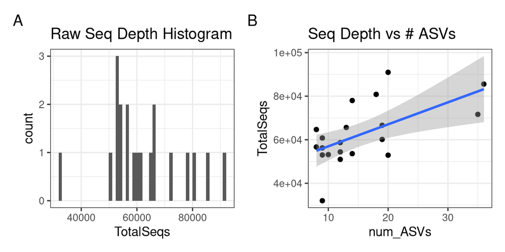

```r
# Put the two plots together.
rawSeq_histogram + rawSeq_vs_numASV_plot +
  plot_annotation(tag_levels = "A")
```

Interpretation 2: I will scale the reads to the minimum read depth of 32,004 reads. While it is an outlier in terms of the number of reads, the ASV count is on par with the rest of the samples. Therefore, I am not going to remove that sample and keep it as my scaling reference. While I do think scaling a sample with 80,000 reads down to 32,000 reads is something to be aware of, fortunately I do think it is still enough read depth for beta diversity metrics like Bray Curtis. Cheese samples have relatively low diversity making the scaling less of a concern with high read depths.

# 3. Scale Read Counts

```r
min(sample_sums(midpoint_rooted_physeq))
```

```
## [1] 32004
```

```r
# Scale the reads
scaled_physeq <-
  midpoint_rooted_physeq %>%
  scale_reads(round = "matround")

# Look at it
scaled_physeq
```

```
## phyloseq-class experiment-level object
## otu_table()   OTU Table:         [ 93 taxa and 20 samples ]
## sample_data() Sample Data:       [ 20 samples by 45 sample variables ]
## tax_table()   Taxonomy Table:    [ 93 taxa by 9 taxonomic ranks ]
## phy_tree()    Phylogenetic Tree: [ 93 tips and 92 internal nodes ]
```

```r
# Look at it more!
#View(data.frame(otu_table(midpoint_rooted_physeq)))
#View(data.frame(otu_table(scaled_physeq)))

# Confirm seq read depth of scaled_physeq
scaled_TotalSeqs_df <-
  scaled_physeq %>%
  sample_sums() %>%
  data.frame()

colnames(scaled_TotalSeqs_df)[1] <- "TotalSeqs"

# add a new column of num_ASVs (RAW, non-noramlized # ASVs)
scaled_TotalSeqsASVs_df <-
  scaled_TotalSeqs_df %>%
  mutate(num_ASVs = colSums(otu_table(scaled_physeq) > 1))

# Plot it!
scaledSeq_histogram <-
  scaled_TotalSeqs_df %>%
  ggplot(aes(x = TotalSeqs)) +
  geom_histogram(bins = 50) +
  labs(title = "Scaled Seq Depth Histogram") +
  #scale_x_continuous(limits = c(0, 7500)) +
  theme_bw()

# Scaling always gives us a range!
# Minimum sequences
min(scaled_TotalSeqs_df$TotalSeqs)
```

```
## [1] 32002
```

```r
# Total Range
range(scaled_TotalSeqs_df)
```

```
## [1] 32002 32005
```

```r
# How many is that range?
range_seqs <- (max(scaled_TotalSeqs_df$TotalSeqs) - min(scaled_TotalSeqs_df$TotalSeqs))
range_seqs
```

```
## [1] 3
```

```r
# And in terms of percent?
range_seqs/max(scaled_TotalSeqs_df$TotalSeqs)
```

```
## [1] 9.373535e-05
```

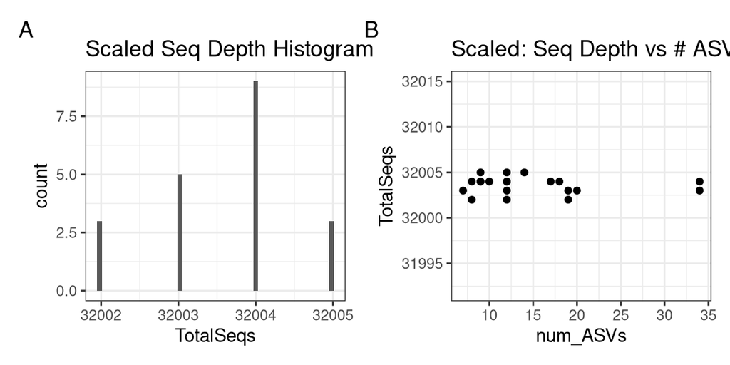

```r
#View(scaled_TotalSeqs_df)

# Set the axis min and max for the next plot
max_y <- max(scaled_TotalSeqs_df$TotalSeqs) + 10
min_y <- min(scaled_TotalSeqs_df$TotalSeqs) - 10

# Now, draw the plot
scaledSeq_vs_numASV_plot <-
  scaled_TotalSeqsASVs_df %>%
  ggplot(aes(x = num_ASVs, y = TotalSeqs)) +
  geom_point() +
  scale_y_continuous(limits = c(min_y, max_y)) +
  #geom_smooth(method = "lm") +
  theme_bw() +
  labs(title = "Scaled: Seq Depth vs # ASVs")

# Put the two plots together.
scaledSeq_histogram + scaledSeq_vs_numASV_plot +
  plot_annotation(tag_levels = "A")
```

# Beta Diversity: Dissimilarity Metrics in Microbial Ecology

## Five Types of Dissimilarities

### B. Sorensen-Dice Dissimilarity

### C. Bray-Curtis Dissimilarity

### D. Unweighted UniFrac Dissimilarity

### E. Weighted UniFrac Dissimilarity

# 4. Calculating dissimilarity

```r
# Sorensen Dissimiliarty
scaled_sorensen_dist <- phyloseq::distance(scaled_physeq, method = "bray", binary = TRUE)

# What does it look like?
class(scaled_sorensen_dist)
```

```
## [1] "dist"
```

```r
str(scaled_sorensen_dist)
```

```
##  'dist' num [1:190] 0.524 0.444 0.565 0.714 0.714 ...
##  - attr(*, "maxdist")= num 1
##  - attr(*, "Size")= int 20
##  - attr(*, "Labels")= chr [1:20] "SRR9722160" "SRR9722161" "SRR9722162" "SRR9722163" ...
##  - attr(*, "Diag")= logi FALSE
##  - attr(*, "Upper")= logi FALSE
##  - attr(*, "method")= chr "binary bray"
##  - attr(*, "call")= language vegdist(x = c(0, 0, 0, 0, 0, 0, 0, 0, 0, 0, 0, 0, 0, 0, 0, 15, 0, 0, 0,  0, 0, 0, 0, 0, 0, 0, 0, 0, 0, 0, 0, 0, 0| __truncated__ ...
```

```r
#head(as.matrix(scaled_sorensen_dist))

# Bray-Curtis Dissimiliarty
scaled_bray_dist <- phyloseq::distance(scaled_physeq, method = "bray", binary = FALSE)

# Abundance-Unweighted UniFrac
scaled_uUnifrac_dist <- phyloseq::distance(scaled_physeq, method = "unifrac")

# Abundance-Weighted UniFrac
scaled_wUnifrac_dist <- phyloseq::distance(scaled_physeq, method = "wunifrac")
```

Interpretation 4: The scientific question from my project is if cheese type affects the microbial diversity. To answer this question, we can use the Sorensen to detect differences in the presence/absence of bacteria in different cheese types focusing on the shared taxa. From there, we can look at Bray Curtis because sensitive to both composition and abundance, which is important for cheese where certain taxa dominate the matrix. Lastly, an weighted UniFrac could be an interesting layer by considering how evolutionarily different microbial communities are between different cheeses. Maybe this is too much fo a strech for this metric, but I think it can help reveal microbial differences that relate to visible and functional differences in cheese, like holes, aging characteristics, or flavor profiles based on phylogeny.

# 5a. PERMANOVA: Testing Means/Centroids

Since I am working with categorical data only, and most of the metadata is the same, then I am just going to see the effect that cheese has in the Sorensen and Bray Curtis model. I don’t have enough information for anything else to have that be a factor to consider in analysis or composition.

### Sorensen

```r
# Sorensen
## 1. Run with by = terms for R² values, sensitive to order of variables!
sorensen_cheese_adonis_terms1 <- adonis2(scaled_sorensen_dist ~ cheese_type * cheese_id, data = metadata_df, by = "terms")
sorensen_cheese_adonis_terms1
```

```
## Permutation test for adonis under reduced model
## Terms added sequentially (first to last)
## Permutation: free
## Number of permutations: 999
##
## adonis2(formula = scaled_sorensen_dist ~ cheese_type * cheese_id, data = metadata_df, by = "terms")
##                       Df SumOfSqs      R2      F Pr(>F)
## cheese_type            3   1.5559 0.47765 5.0762  0.001 ***
## cheese_id              1   0.2084 0.06399 2.0402  0.062 .
## cheese_type:cheese_id  3   0.2671 0.08199 0.8713  0.641
## Residual              12   1.2260 0.37638
## Total                 19   3.2574 1.00000
## ---
## Signif. codes:  0 '***' 0.001 '**' 0.01 '*' 0.05 '.' 0.1 ' ' 1
```

```r
#change interaction order
sorensen_cheese_adonis_terms2 <- adonis2(scaled_sorensen_dist ~ cheese_id * cheese_type, data = metadata_df, by = "terms")
sorensen_cheese_adonis_terms2
```

```
## Permutation test for adonis under reduced model
## Terms added sequentially (first to last)
## Permutation: free
## Number of permutations: 999
##
## adonis2(formula = scaled_sorensen_dist ~ cheese_id * cheese_type, data = metadata_df, by = "terms")
##                       Df SumOfSqs      R2      F Pr(>F)
## cheese_id              1   0.2381 0.07309 2.3302  0.033 *
## cheese_type            3   1.5263 0.46855 4.9796  0.001 ***
## cheese_id:cheese_type  3   0.2671 0.08199 0.8713  0.629
## Residual              12   1.2260 0.37638
## Total                 19   3.2574 1.00000
## ---
## Signif. codes:  0 '***' 0.001 '**' 0.01 '*' 0.05 '.' 0.1 ' ' 1
```

```r
## 2. Run with by = "margin" for marginal p-values, which we can compare to the residuals from the first one.
sorensen_cheese_adonis_margin <- adonis2(scaled_sorensen_dist ~ cheese_type * cheese_id, data = metadata_df, by = "margin")
sorensen_cheese_adonis_margin
```

```
## Permutation test for adonis under reduced model
## Marginal effects of terms
## Permutation: free
## Number of permutations: 999
##
## adonis2(formula = scaled_sorensen_dist ~ cheese_type * cheese_id, data = metadata_df, by = "margin")
##                       Df SumOfSqs      R2      F Pr(>F)
## cheese_type:cheese_id  3   0.2671 0.08199 0.8713  0.643
## Residual              12   1.2260 0.37638
## Total                 19   3.2574 1.00000
```

Now let’s do the Bray Curtis with categorical data.

### Bray-Curtis

```r
# Bray-Curtis
bray_cheese_adonis_terms1 <- adonis2(scaled_bray_dist ~ cheese_type * cheese_id, data = metadata_df, by = "terms")
bray_cheese_adonis_terms1
```

```
## Permutation test for adonis under reduced model
## Terms added sequentially (first to last)
## Permutation: free
## Number of permutations: 999
##
## adonis2(formula = scaled_bray_dist ~ cheese_type * cheese_id, data = metadata_df, by = "terms")
##                       Df SumOfSqs      R2      F Pr(>F)
## cheese_type            3  0.97668 0.44336 4.5854  0.003 **
## cheese_id              1  0.25467 0.11561 3.5869  0.037 *
## cheese_type:cheese_id  3  0.11954 0.05426 0.5612  0.731
## Residual              12  0.85200 0.38676
## Total                 19  2.20288 1.00000
## ---
## Signif. codes:  0 '***' 0.001 '**' 0.01 '*' 0.05 '.' 0.1 ' ' 1
```

```r
# change term order
bray_cheese_adonis_terms2 <- adonis2(scaled_bray_dist ~ cheese_type * cheese_id, data = metadata_df, by = "terms")
bray_cheese_adonis_terms2
```

```
## Permutation test for adonis under reduced model
## Terms added sequentially (first to last)
## Permutation: free
## Number of permutations: 999
##
## adonis2(formula = scaled_bray_dist ~ cheese_type * cheese_id, data = metadata_df, by = "terms")
##                       Df SumOfSqs      R2      F Pr(>F)
## cheese_type            3  0.97668 0.44336 4.5854  0.005 **
## cheese_id              1  0.25467 0.11561 3.5869  0.047 *
## cheese_type:cheese_id  3  0.11954 0.05426 0.5612  0.723
## Residual              12  0.85200 0.38676
## Total                 19  2.20288 1.00000
## ---
## Signif. codes:  0 '***' 0.001 '**' 0.01 '*' 0.05 '.' 0.1 ' ' 1
```

```r
## 2. Run with by = "margin" for marginal p-values
bray_cheese_adonis_margin <- adonis2(scaled_bray_dist ~ cheese_type * cheese_id, data = metadata_df, by = "margin")
bray_cheese_adonis_margin
```

```
## Permutation test for adonis under reduced model
## Marginal effects of terms
## Permutation: free
## Number of permutations: 999
##
## adonis2(formula = scaled_bray_dist ~ cheese_type * cheese_id, data = metadata_df, by = "margin")
##                       Df SumOfSqs      R2      F Pr(>F)
## cheese_type:cheese_id  3  0.11954 0.05426 0.5612  0.732
## Residual              12  0.85200 0.38676
## Total                 19  2.20288 1.00000
```

Interpretation 5: For my PERMANOVA analysis I chose to look at the interaction of `cheese_type` and `cheese_id`. I chose these two because the `chese_id` is the tag I used to assign `cheese_type` so in essence, it is the same variable.

Overall, from here we can reject the null hypothesis and conclude that the microbial diversity is related to the cheese type.

# 5b. Betadisper: Testing Variances/Dispersions

## Sorensen

```r
# Homogeneity of Disperson test with beta dispr
# Sorensen Betadisper - cheese type
dispr_sorensen_cheese_type <- betadisper(scaled_sorensen_dist, metadata_df$cheese_type)
# permutest() performs a non-parametric permutation test, which is robust and valid for the kind of data used in beta diversity analysis (e.g., dissimilarity matrices).
permutest(dispr_sorensen_cheese_type)
```

```
##
## Permutation test for homogeneity of multivariate dispersions
## Permutation: free
## Number of permutations: 999
##
## Response: Distances
##           Df   Sum Sq   Mean Sq      F N.Perm Pr(>F)
## Groups     3 0.037168 0.0123894 1.3696    999  0.286
## Residuals 16 0.144732 0.0090458
```

```r
# Sorensen Betadisper - cheese id
dispr_sorensen_cheese_id <- betadisper(scaled_sorensen_dist, metadata_df$cheese_id)
permutest(dispr_sorensen_cheese_id)
```

```
##
## Permutation test for homogeneity of multivariate dispersions
## Permutation: free
## Number of permutations: 999
##
## Response: Distances
##           Df Sum Sq Mean Sq   F N.Perm Pr(>F)
## Groups    19      0       0 NaN    999
## Residuals  0      0     NaN
```

## Bray-Curtis

```r
# Bray-Curtis Betadisper - cheese type
dispr_bray_cheese_type <- betadisper(scaled_bray_dist, metadata_df$cheese_type)
permutest(dispr_bray_cheese_type)
```

```
##
## Permutation test for homogeneity of multivariate dispersions
## Permutation: free
## Number of permutations: 999
##
## Response: Distances
##           Df  Sum Sq  Mean Sq      F N.Perm Pr(>F)
## Groups     3 0.27901 0.093003 2.2314    999  0.122
## Residuals 16 0.66687 0.041680
```

```r
# Bray-Curtis Betadisper - cheese id
dispr_bray_cheese_id <- betadisper(scaled_bray_dist, metadata_df$cheese_id)
permutest(dispr_bray_cheese_id)
```

```
##
## Permutation test for homogeneity of multivariate dispersions
## Permutation: free
## Number of permutations: 999
##
## Response: Distances
##           Df Sum Sq Mean Sq   F N.Perm Pr(>F)
## Groups    19      0       0 NaN    999
## Residuals  0      0     NaN
```

Interpretation 6:Regardless of Sorensen and Bray Curtis, there is no significant difference in beta-dispersion (community variability) among cheese types. Even though cheese types may differ in composition, the amount of microbial variation within each cheese type is roughly the same. No cheese type had samples that were consistently more similar (tight clustering) or more variable (scattered) than others.

Interpretation 7: Cheese type has a significant effect on the microbial community composition, explaining nearly half of the variation in the data. However, the variation within each cheese type group is similar, meaning differences detected by PERMANOVA are not just due to one group being more variable.

Cheese type significantly influences the composition of the microbial communities found in cheese samples. This difference is not due to uneven variation within cheese groups (since dispersions are homogenous), but rather reflects meaningful shifts in microbial structure between cheese types. Therefore, cheese type plays a strong and consistent role in shaping the microbial landscape of the samples.

# 6. Visualize Community Dissimilarity with Ordination

# 6a. PCoA: Principal Coordinates Analysis

```r
# back it up...so i ran this and had so many problems and that is when it hit me--my cheese_type is NOT in my physeq object! so lets add that and see if it fixes some of my problems

# Manually create a lookup table
cheese_lookup <- data.frame(
  srr_id = c("SRR9722160", "SRR9722161", "SRR9722162", "SRR9722163", "SRR9722164",
             "SRR9722165", "SRR9722166", "SRR9722167", "SRR9722168", "SRR9722169",
             "SRR9722170", "SRR9722171", "SRR9722172", "SRR9722173", "SRR9722174",
             "SRR9722175", "SRR9722176", "SRR9722177", "SRR9722178", "SRR9722179"),
  sample_name = c("Q11", "Q12", "Q13", "Q14", "Q1",
                  "Q2", "Q17", "Q18", "Q19", "Q20",
                  "Q6", "Q9", "Q10", "Q3", "Q7",
                  "Q5", "Q8", "Q16", "Q15", "Q4")
)

# Add cheese type based on sample name
cheese_lookup$cheese_type <- case_when(
  cheese_lookup$sample_name %in% c("Q4", "Q5", "Q6", "Q7", "Q8") ~ "Colonial",
  cheese_lookup$sample_name %in% c("Q1", "Q10", "Q2", "Q3", "Q9") ~ "Feta-type",
  cheese_lookup$sample_name %in% c("Q15", "Q14", "Q13", "Q12", "Q11") ~ "Fresh",
  cheese_lookup$sample_name %in% c("Q16", "Q17", "Q18", "Q19", "Q20") ~ "Pecorino-type",
  TRUE ~ NA_character_
)

# Convert sample_data to data frame
sample_meta <- as(sample_data(scaled_physeq), "data.frame") %>%
  rownames_to_column(var = "srr_id") %>%
  left_join(cheese_lookup, by = "srr_id") %>%
  column_to_rownames(var = "srr_id")

# Reassign to phyloseq
sample_data(scaled_physeq) <- sample_data(sample_meta)

table(sample_data(scaled_physeq)$cheese_type, useNA = "always")
```

```
##
##      Colonial     Feta-type         Fresh Pecorino-type          <NA>
##             5             5             5             5             0
```

```r
### SORENSEN
# First, calculate PCoA with Soresen
scaled_soren_pcoa <-
  ordinate(physeq = scaled_physeq,
         method = "PCoA",
         distance = "bray", binary = TRUE)

# Take a quick look
str(scaled_soren_pcoa)
```

```
## List of 5
##  $ correction: chr [1:2] "none" "1"
##  $ note      : chr "No correction was applied to the negative eigenvalues"
##  $ values    :'data.frame':  20 obs. of  6 variables:
##   ..$ Eigenvalues   : num [1:20] 1.111 0.558 0.49 0.306 0.255 ...
##   ..$ Relative_eig  : num [1:20] 0.3411 0.1713 0.1503 0.0939 0.0784 ...
##   ..$ Rel_corr_eig  : num [1:20] 0.2807 0.1465 0.1299 0.0853 0.073 ...
##   ..$ Broken_stick  : num [1:20] 0.1942 0.1386 0.1108 0.0923 0.0784 ...
##   ..$ Cum_corr_eig  : num [1:20] 0.281 0.427 0.557 0.642 0.715 ...
##   ..$ Cumul_br_stick: num [1:20] 0.194 0.333 0.444 0.536 0.614 ...
##  $ vectors   : num [1:20, 1:13] 0.168 -0.069 0.13 0.11 -0.213 ...
##   ..- attr(*, "dimnames")=List of 2
##   .. ..$ : chr [1:20] "SRR9722160" "SRR9722161" "SRR9722162" "SRR9722163" ...
##   .. ..$ : chr [1:13] "Axis.1" "Axis.2" "Axis.3" "Axis.4" ...
##  $ trace     : num 3.26
##  - attr(*, "class")= chr "pcoa"
```

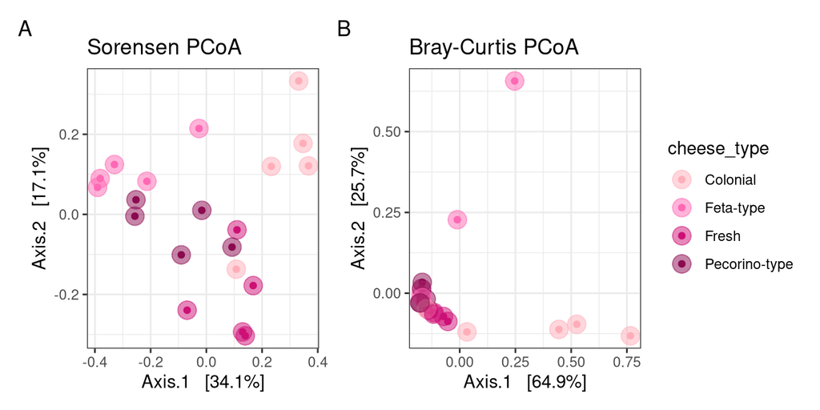

```r
# Plot it: Sorensen PCoA
sorensen_pcoa_plot <-
  plot_ordination(physeq = scaled_physeq,
                  ordination = scaled_soren_pcoa,
                  color = "cheese_type",
                  title = "Sorensen PCoA") +
  scale_color_manual(values = cheese_colors) +
  scale_shape_manual(values = c(15, 16, 17)) +
  geom_point(size = 5, alpha = 0.5) +
  theme_bw() +
  theme(legend.position = "right")


### Bray-Curtis
# Second, calculate PCoA with Bray-Curtis
scaled_bray_pcoa <-
  ordinate(physeq = scaled_physeq,
         method = "PCoA",
         distance = "bray", binary = FALSE)

# Plot it: Bray-Curtis PCoA
bray_pcoa_plot <-
  plot_ordination(physeq = scaled_physeq,
                  ordination = scaled_bray_pcoa,
                  color = "cheese_type",
                  title = "Bray-Curtis PCoA") +
  scale_color_manual(values = cheese_colors) +
  scale_shape_manual(values = c(15, 16, 17)) +
  geom_point(size = 5, alpha = 0.5) +
  theme_bw() +
  theme(legend.position = "right")

# Show the plots
sorensen_pcoa_plot + bray_pcoa_plot +
  plot_layout(guides = "collect") +
  plot_annotation(tag_levels = "A")
```

## 6b. NMDS: Non-Metric Multidimensional Scaling

```r
#hmm there is another error in this...let's see what we can trouble shoot
head(sample_data(scaled_physeq))
```

[output not shown]

[output cut: 22 more lines]

[output not shown]

```r
str(sample_data(scaled_physeq)) #silly me all this work to notice a typo
```

[output not shown]

```r
## SORENSEN
scaled_soren_nmds <-
  ordinate(physeq = scaled_physeq,
         method = "NMDS",
         distance = "bray", binary = TRUE)
```

```
## Square root transformation
## Wisconsin double standardization
## *** Best solution repeated 3 times
```

```r
# Plot it!
sorensen_nmds_plot <-
  plot_ordination(physeq = scaled_physeq,
                ordination = scaled_soren_nmds,
                color = "cheese_type",
                title = "Sorensen NMDS") +
  scale_color_manual(values = cheese_colors) +
  geom_point(size = 5, alpha = 0.5) +
  labs(subtitle = "Stress = 0.153") +
  theme_bw() +
  theme(legend.position = "right")

### Bray-Curtis
# Second, calculate NMDS with Bray-Curtis
scaled_bray_nmds <-
  ordinate(physeq = scaled_physeq,
         method = "NMDS",
         distance = "bray", binary = FALSE)
```

```
## Square root transformation
## Wisconsin double standardization
## *** Best solution repeated 4 times
```

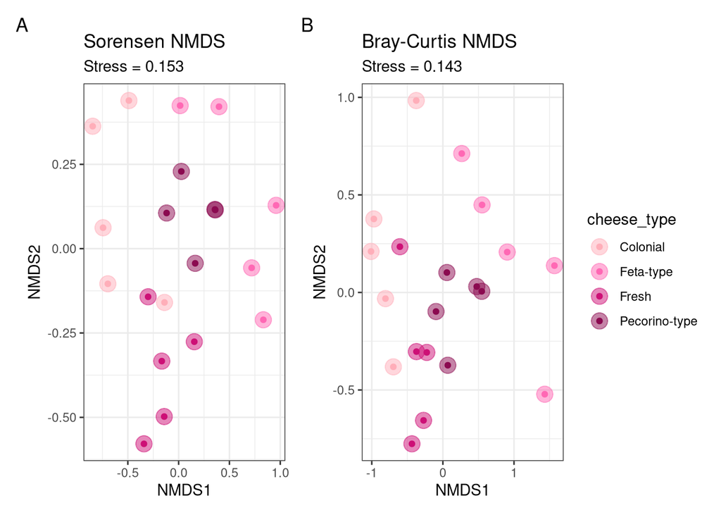

```r
# Plot it: Bray-Curtis NMDS
bray_nmds_plot <-
  plot_ordination(physeq = scaled_physeq,
                ordination = scaled_bray_nmds,
                color = "cheese_type",
                title = "Bray-Curtis NMDS") +
  scale_color_manual(values = cheese_colors) +
  geom_point(size = 5, alpha = 0.5) +
  labs(subtitle = "Stress = 0.143")+
  theme_bw() +
  theme(legend.position = "right")

# Show the plots
sorensen_nmds_plot + bray_nmds_plot +
  plot_layout(guides = "collect") +
  plot_annotation(tag_levels = "A")
```

## All ordinations together!

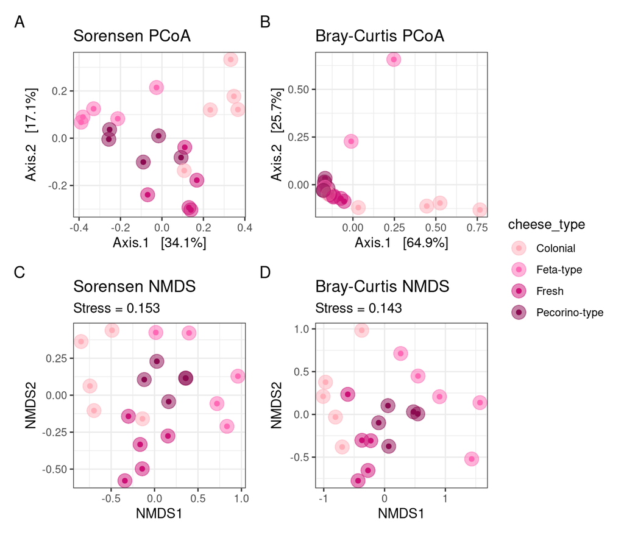

```r
sorensen_pcoa_plot + bray_pcoa_plot +
sorensen_nmds_plot + bray_nmds_plot +
  plot_layout(guides = "collect") +
  plot_annotation(tag_levels = "A")
```

# Final info for Reproducibility

## Check Render Time

```r
# Take the time now that we are at the end of the script
end_time <- Sys.time()
end_time
```

```
## [1] "2025-04-17 23:23:11 EDT"
```

```r
# Echo the elapsed time
elapsed_time <- round((end_time - start_time), 3)
elapsed_time
```

```
## Time difference of 9.166 secs
```